# The Spatial Relationship Between Campsites, Homelessness Services, and Drug Offenses by Portland, OR Neighborhoods between 2025-2025

Group 5 - Logan Rossell & Talia Walderman

The number of homeless individuals in Portland, OR has increased over time from 11,430 at the start of 2024 to 18,260 individuals, according to the Homeless Services Department. We sought to explore the spatial relationship between homelessness in a neighborhood, available services, and documented crime in an effort to understand where areas of Portland, OR are underserving its unsheltered residents.

https://github.com/LoganRosell/data_viz_homelessness_project_public_repo.git

## Regression

### Overly Simplistic Regression

Throwing all our variables into a linear regression produced a model with a high R-squared value, but it does not satisfy the assumptions of linear regression, thus making this a misleading model.

```
##
## Call:
## lm(formula = clean_site_count ~ `Assault Offenses` + Burglary +
##     `Extortion/Blackmail` + shelter_count + crime_count + Embezzlement +
##     `Counterfeiting/Forgery` + `Homicide Offenses` + `Drug/Narcotic Offenses` +
##     `Human Trafficking Offenses` + `Stolen Property Offenses`,
##     data = combined_counts)
##
## Residuals:
##      Min       1Q   Median       3Q      Max
## -156.656  -58.857   -3.524   46.199  289.891
##
## Coefficients:
##                               Estimate Std. Error t value Pr(>|t|)
## (Intercept)                  -18.18396   19.28548  -0.943  0.35019
## `Assault Offenses`             1.55444    0.52509   2.960  0.00465 **
## Burglary                       2.89956    0.54994   5.273 2.75e-06 ***
## `Extortion/Blackmail`        -73.88830   22.58881  -3.271  0.00192 **
## shelter_count                 19.57547   16.54793   1.183  0.24231
## crime_count                   -0.12075    0.05049  -2.392  0.02051 *
## Embezzlement                 -26.09480   17.40983  -1.499  0.14008
## `Counterfeiting/Forgery`     -15.99550    4.56316  -3.505  0.00096 ***
## `Homicide Offenses`           39.26796   11.86486   3.310  0.00172 **
## `Drug/Narcotic Offenses`       3.49768    1.67977   2.082  0.04236 *
## `Human Trafficking Offenses` -84.89174   43.24575  -1.963  0.05511 .
## `Stolen Property Offenses`    39.12280   22.10132   1.770  0.08268 .
## ---
## Signif. codes:  0 '***' 0.001 '**' 0.01 '*' 0.05 '.' 0.1 ' ' 1
##
## Residual standard error: 88.08 on 51 degrees of freedom
##   (59 observations deleted due to missingness)
## Multiple R-squared:  0.9038, Adjusted R-squared:  0.883
## F-statistic: 43.55 on 11 and 51 DF,  p-value: < 2.2e-16
```

### Nuanced Regression

Accounting for population variation between neighborhoods and for the non-linearity of the data produces a more accurate but less intuitive model, which serves as a reminder to question the preconceived notions we all hold about homelessness.

```
##
## Call:
## lm(formula = log_clean_sites_per_capita ~ Vandalism_per_capita +
##     Burglary_per_capita + `Weapon Law Violations_per_capita` +
##     library_count_per_capita + pov, data = model_data)
##
## Residuals:
##      Min       1Q   Median       3Q      Max
## -1.46182 -0.43756 -0.01352  0.48763  1.69611
##
## Coefficients:
##                                     Estimate Std. Error t value Pr(>|t|)
## (Intercept)                          -5.3353     0.2324 -22.956   <2e-16 ***
## Vandalism_per_capita                 33.7920    15.4288   2.190   0.0329 *
## Burglary_per_capita                  36.0906    13.5229   2.669   0.0101 *
## `Weapon Law Violations_per_capita`  283.0522   110.1695   2.569   0.0130 *
## library_count_per_capita           1400.8274  1387.6714   1.009   0.3173
## pov                                  -0.5597     1.8190  -0.308   0.7595
## ---
## Signif. codes:  0 '***' 0.001 '**' 0.01 '*' 0.05 '.' 0.1 ' ' 1
##
## Residual standard error: 0.7402 on 53 degrees of freedom
##   (63 observations deleted due to missingness)
## Multiple R-squared:   0.61,  Adjusted R-squared:  0.5733
## F-statistic: 16.58 on 5 and 53 DF,  p-value: 7.876e-10
```

## Visualizations

### Choropleth Map - Homeless Campsites Cleaned by the IRP

#### What is the IRP?

“The Impact Reduction Program is designed to be a stopgap measure that addresses the issues of hygiene, waste management, and public access that arise as a result of unsheltered homelessness. The program treats the symptoms of the problem of homelessness, but is not designed to be a root cause solution to homelessness.” Source: https://www.portland.gov/homelessness-impact-reduction/overview

[interactive chart not shown]

### Homelessness Services Offered in Portland, OR

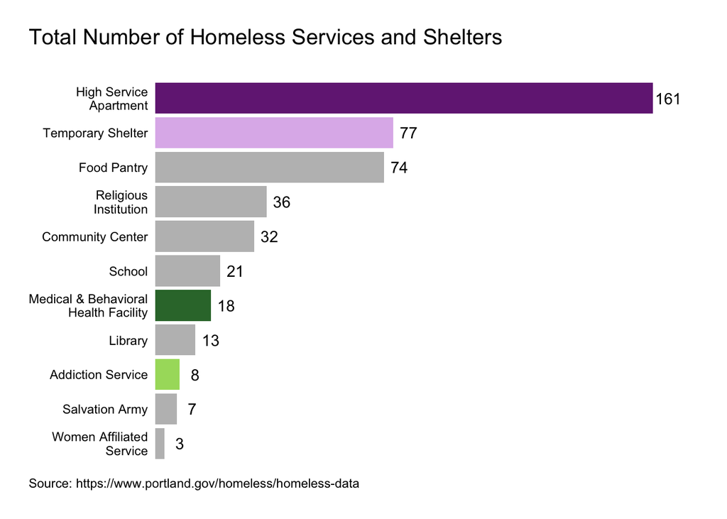

### Where Shelters and Health Care Services are Located

[interactive chart not shown]